# Summary report for Wilcot

UKMON

2017-07-18

# Summary of activity in 2017

Wilcot operates 8 cameras.

In 2017 Wilcot has recorded 5305 individual meteor observations. These observations comprise 1196 sporadic meteors and 4109 stream meteors. A breakdown by month is shown below.

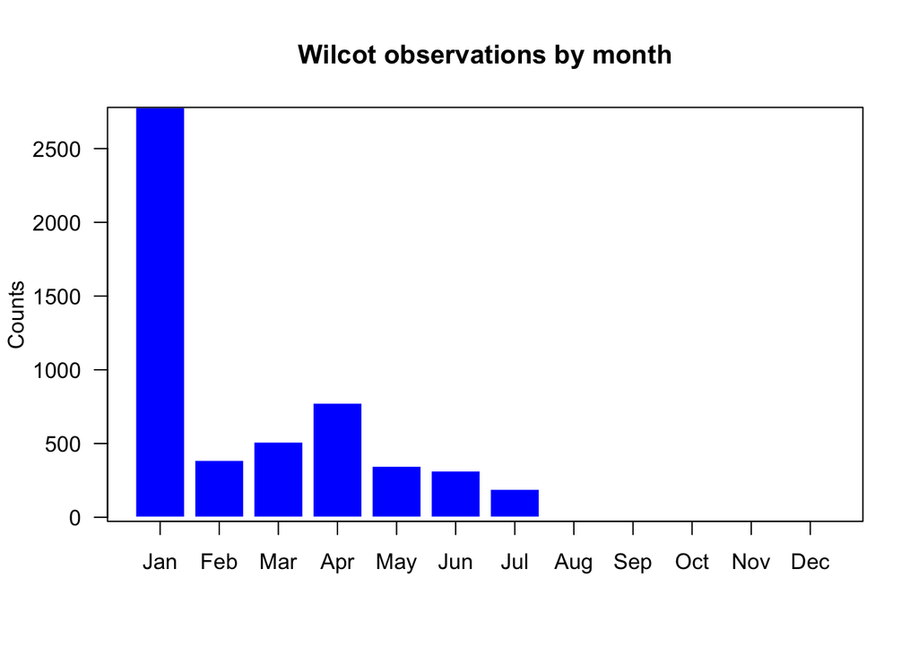

The following shows observation counts by stream for the 20 most frequent showers based on preliminary UFO ANALYSIS classifications:

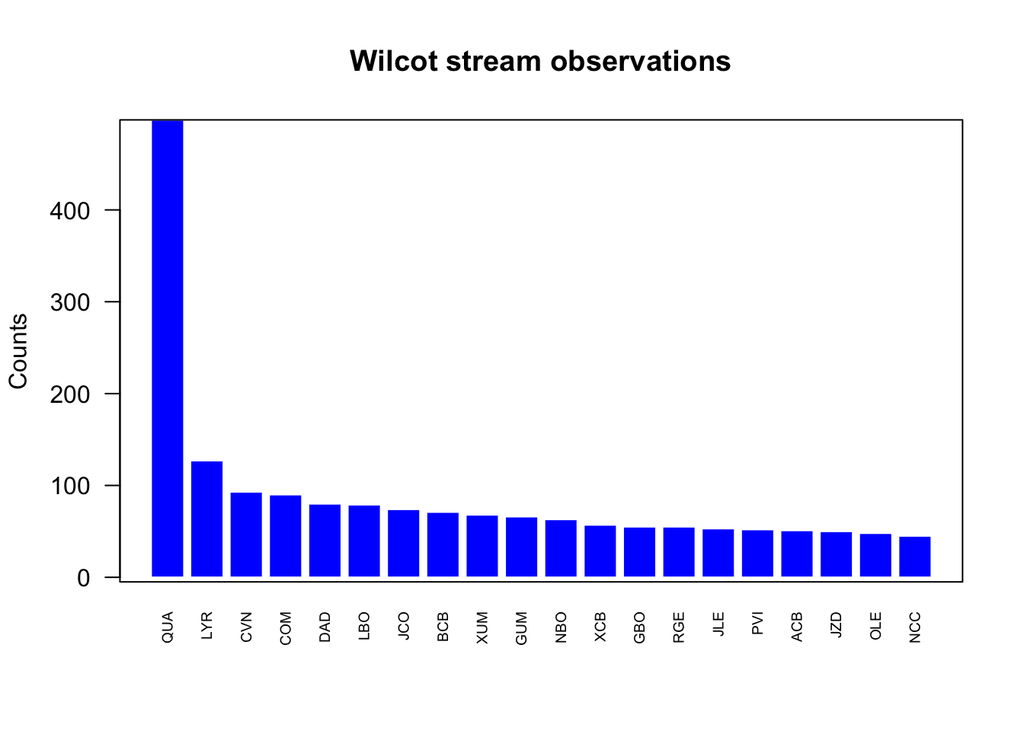

The following table shows which stations are generating matched observations with this station and the number of matches:

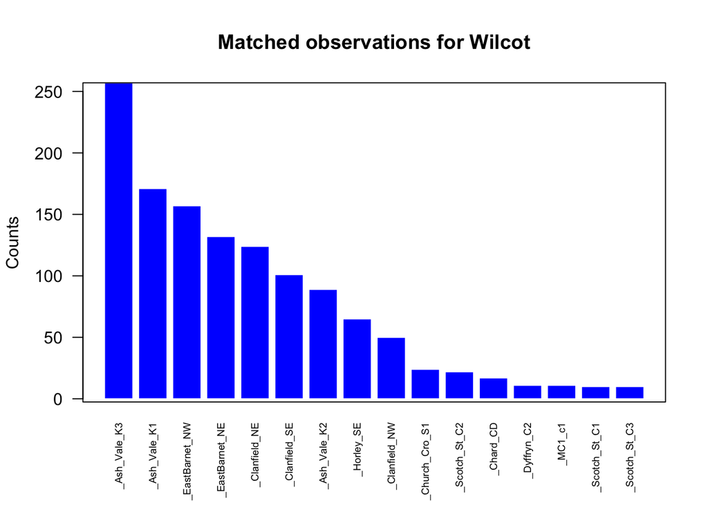

## Fireball activity

(Based on IAU definition of apparrent magnitude of -4.0 of greater)

| Datetime | Magnitude | Duration | Stream |
| --- | --- | --- | --- |
| 2017-06-01 22:38:39 | -6.6 | 1.76 | SPO |
| 2017-01-14 05:22:09 | -5.7 | 0.62 | LBO |
| 2017-04-23 02:26:06 | -5.7 | 0.24 | LYR |
| 2017-03-25 00:03:36 | -5.3 | 1.30 | FHE |
| 2017-01-19 05:33:22 | -5.2 | 0.62 | XUM |
| 2017-01-03 07:33:33 | -4.7 | 0.16 | QUA |
| 2017-01-03 06:49:29 | -4.6 | 0.76 | JCO |
| 2017-03-24 00:06:20 | -4.6 | 1.50 | ACO |
| 2017-06-01 22:38:39 | -4.5 | 0.74 | PSP |
| 2017-04-23 02:26:06 | -4.2 | 0.42 | LYR |
| 2017-01-03 17:41:45 | -4.0 | 0.20 | QUA |
| 2017-01-19 05:33:22 | -4.0 | 0.88 | RGE |

# Observations recorded by Wilcot, 2013 to 2017

UKMON data for Wilcot covers the period from 2013 to 2017 and totals 45835 individual meteor observations. These observations comprise 8224 sporadic meteors and 37611 stream meteors.

This section provides a summary of all observations by Wilcot from 2013 to 2017. A breakdown of the number of observations by year is given in the histogram below.

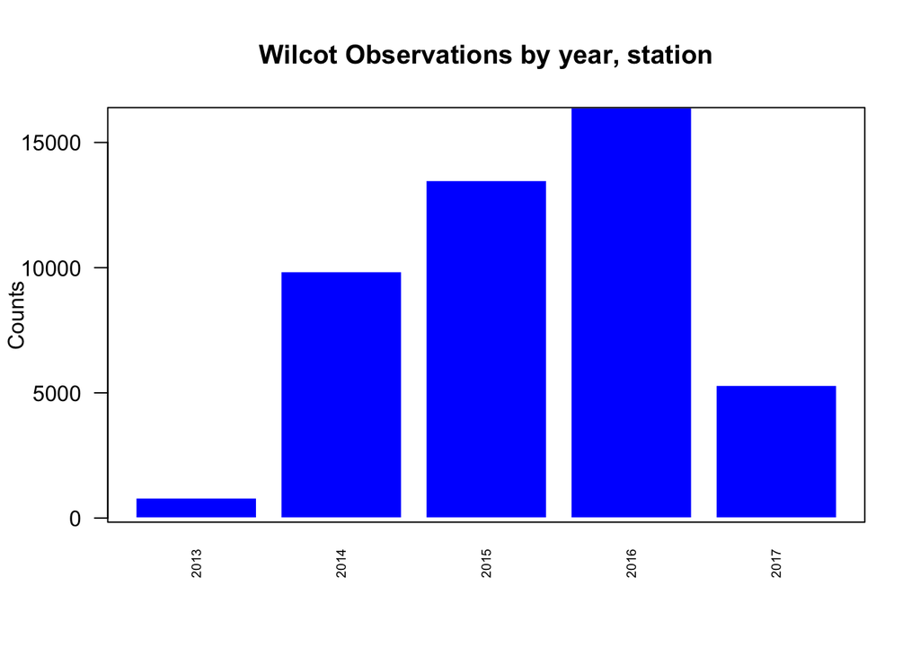

The following graph shows observation counts by stream (preliminary UFO ANALYSIS classification). A detailed breakdown by shower is given in the table at the end of this report.

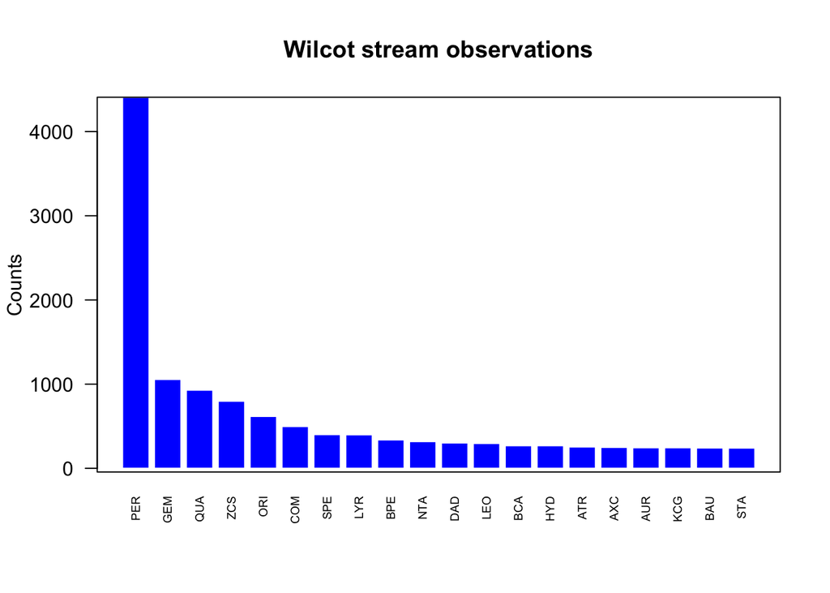

## Fireball activity

Fireballs recorded (Based on IAU definition of apparrent magnitude of -4.0 of greater)

| Datetime | Magnitude | Duration | Stream |
| --- | --- | --- | --- |
| 2015-08-12 20:58:59 | -8.4 | 0.72 | PER |
| 2014-06-30 02:04:24 | -8.0 | 2.44 | SPO |
| 2016-03-17 03:16:55 | -7.2 | 1.68 | PDF |
| 2017-06-01 22:38:39 | -6.6 | 1.76 | SPO |
| 2016-02-02 23:23:44 | -6.5 | 2.14 | SPO |
| 2016-10-26 18:09:28 | -6.4 | 0.86 | XDR |
| 2016-12-19 04:44:38 | -6.2 | 4.24 | SPO |
| 2015-11-21 00:25:37 | -6.1 | 0.64 | SPO |
| 2016-08-12 03:09:56 | -6.1 | 0.64 | SAQ |
| 2014-08-13 02:53:24 | -6.0 | 0.80 | BPE |
| 2016-08-12 03:09:57 | -6.0 | 0.42 | ADC |
| 2015-08-11 01:48:08 | -5.9 | 0.94 | MPR |
| 2015-12-05 05:27:39 | -5.9 | 0.54 | DAB |
| 2016-08-11 23:12:19 | -5.7 | 1.02 | PER |
| 2017-01-14 05:22:09 | -5.7 | 0.62 | LBO |
| 2017-04-23 02:26:06 | -5.7 | 0.24 | LYR |
| 2015-10-31 22:28:54 | -5.6 | 2.40 | NTA |
| 2016-12-05 02:23:37 | -5.6 | 1.34 | HYD |
| 2014-08-12 01:23:15 | -5.4 | 0.88 | MPR |
| 2014-08-13 01:31:54 | -5.4 | 0.24 | PER |
| 2014-11-02 21:15:35 | -5.4 | 0.48 | OLY |
| 2014-11-24 06:18:28 | -5.4 | 0.42 | UUM |
| 2015-10-26 04:47:18 | -5.4 | 0.38 | ORI |
| 2015-11-01 01:11:22 | -5.4 | 0.72 | STA |
| 2016-05-05 03:40:20 | -5.4 | 0.90 | ETA |
| 2016-08-11 23:12:19 | -5.4 | 0.88 | PER |
| 2014-11-02 21:15:35 | -5.3 | 0.60 | PAR |
| 2015-07-19 22:40:42 | -5.3 | 0.88 | SPO |
| 2015-11-08 20:12:48 | -5.3 | 1.38 | NTA |
| 2016-12-22 03:18:59 | -5.3 | 0.44 | COM |

[output cut: 87 more lines]

The following table shows which stations are generating matched observations with this station and the number of matches:

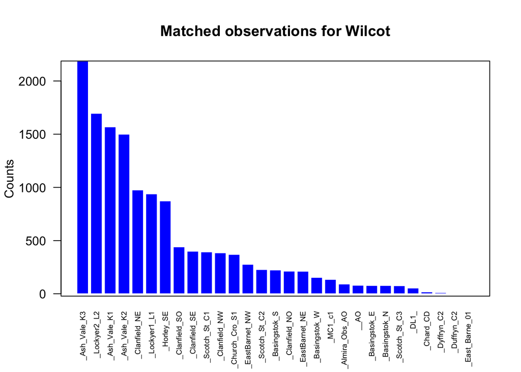

# Detailed counts (including sporadics)

| Shower | Counts |
| --- | --- |
| SPO | 8224 |
| PER | 4408 |
| GEM | 1056 |
| QUA | 929 |
| ZCS | 798 |
| ORI | 617 |
| COM | 497 |
| SPE | 401 |
| LYR | 399 |
| BPE | 338 |
| NTA | 318 |
| DAD | 302 |
| LEO | 296 |
| BCA | 269 |
| HYD | 269 |
| ATR | 254 |
| AXC | 249 |
| AUR | 245 |
| KCG | 245 |
| BAU | 242 |
| STA | 241 |
| AGC | 237 |
| XAU | 231 |
| TRI | 230 |
| AIC | 226 |
| SIC | 218 |
| DAU | 216 |
| EGE | 214 |
| CVN | 211 |
| TPI | 204 |

[output cut: 393 more lines]